# Simple Neural Network

## Source

Stat 665 Course Lecture Notes from Yale: by Taylor Arnold.

## Simple neural network

- Support for running modern, deep, neural networks in R is quite weak.
- Here we’ll see how to use the two most popular packages.
- To start, let’s load in the cars dataset:

## Cars Dataset

```r
set.seed(1)
x <- read.csv("datasets/cars.csv", as.is=TRUE)
names(x) <- tolower(names(x))
x$expensive <- as.numeric(x$retail > median(x$retail))
x$testFlag <- as.numeric(runif(nrow(x)) > 0.8)
dim(x)
```

```
## [1] 387  20
```

## Cars dataset

```r
head(x)
```

```
##                         sports suv wagon minivan pickup awd rwd retail
## Acura 3.5 RL                 0   0     0       0      0   0   0  43755
## Acura 3.5 RL Navigation      0   0     0       0      0   0   0  46100
## Acura MDX                    0   1     0       0      0   1   0  36945
## Acura NSX S                  1   0     0       0      0   0   1  89765
## Acura RSX                    0   0     0       0      0   0   0  23820
## Acura TL                     0   0     0       0      0   0   0  33195
##                         dealer engine cylinders horsepower citympg
## Acura 3.5 RL             39014    3.5         6        225      18
## Acura 3.5 RL Navigation  41100    3.5         6        225      18
## Acura MDX                33337    3.5         6        265      17
## Acura NSX S              79978    3.2         6        290      17
## Acura RSX                21761    2.0         4        200      24
## Acura TL                 30299    3.2         6        270      20
##                         highwaympg weight wheelbase length width expensive
## Acura 3.5 RL                    24   3880       115    197    72         1
## Acura 3.5 RL Navigation         24   3893       115    197    72         1
## Acura MDX                       23   4451       106    189    77         1
## Acura NSX S                     24   3153       100    174    71         1
## Acura RSX                       31   2778       101    172    68         0
## Acura TL                        28   3575       108    186    72         1
##                         testFlag
## Acura 3.5 RL                   0
## Acura 3.5 RL Navigation        0
## Acura MDX                      0
## Acura NSX S                    1
## Acura RSX                      0
## Acura TL                       1
```

## Logistic Regression

For a point of reference, I’ll fit a logistic regression on the response of whether this car is in the upper half of the dataset in terms of retail price:

Predictors are **weight, citympg, highway mpg, sports (0/1), suv (0/1)*.

```r
out <- glm(expensive ~ weight + citympg + highwaympg + sports + suv,
                  data=x,
                  subset=(testFlag == 0),
                  family=binomial)
glm.probs <- predict(out, x, type='response')
```

## Logistic Regression

```r
glm.pred=rep(0,387)
glm.pred[glm.probs>.5]=1

table(glm.pred[x$testFlag==0],x$expensive[x$testFlag==0])
```

```
##
##       0   1
##   0 130  24
##   1  32 132
```

```r
table(glm.pred[x$testFlag==1],x$expensive[x$testFlag==1])
```

```
##
##      0  1
##   0 29  5
##   1  3 32
```

## Neural Network

Using the **nnet** package, I can fit a neural network with one hidden layers with 10 nodes:

```r
library(nnet)
out <- nnet(expensive ~ weight + citympg + highwaympg + sports + suv,
                  data=x,
                  subset=(testFlag == 0),
                  size=10)
predNnet10 <- predict(out, x)
```

## Outcome

```r
table(predNnet10)
```

```
## predNnet10
## 0.490566038097916
##               387
```

Notice that the prediction results are all the same. In truth, we do not have enough nodes here to learn anything useful.

If I increase this number to 500, the results seem to mimic those of the glm model fairly well.

## Increasing number of nodes

```r
out <- nnet(expensive ~ weight + citympg + highwaympg + sports + suv,
                  data=x, subset=(testFlag == 0), size=500, MaxNWts=7500L)
predNnet500 <- predict(out, x)
```

## Increasing number of nodes

```r
table(round(predNnet500,2))
```

```
##
##    0 0.01 0.02 0.03 0.04 0.05 0.09  0.1 0.11 0.13 0.14 0.16 0.19  0.2 0.21
##  128    3    1    1    1    1    1    1    2    1    1    1    2    2    2
## 0.22 0.23 0.24 0.25 0.26  0.3 0.31 0.32 0.35 0.36 0.37  0.4 0.43 0.44 0.45
##    1    1    1    1    1    1    1    1    1    2    1    1    1    1    1
##  0.5 0.53 0.56 0.57 0.59 0.61 0.62 0.63 0.64 0.65 0.66 0.67 0.69 0.71 0.73
##    2    1    3    1    2    3    1    1    1    3    2    1    1    3    2
## 0.74 0.75 0.76 0.77 0.78 0.79  0.8 0.81 0.82 0.83 0.84
##    1    1    1    8    3    3    4    8    8   26  133
```

```r
cor(predNnet500, glm.probs)
```

```
##           [,1]
## [1,] 0.9151963
```

## Classification Accuracy

```r
nnet500.pred=rep(0,387)
nnet500.pred[ predNnet500 > 0.5]=1
table(nnet500.pred[x$testFlag==0],x$expensive[x$testFlag==0])
```

```
##
##       0   1
##   0 127  11
##   1  35 145
```

```r
table(nnet500.pred[x$testFlag==1],x$expensive[x$testFlag==1])
```

```
##
##      0  1
##   0 25  2
##   1  7 35
```

## Further Increase

Increasing the number of nodes to 900, we see that the correlation actually drops; at this point, the capacity of the model is too large given the input data size.

## Further Increase

```r
out <- nnet(expensive ~ weight + citympg + highwaympg + sports + suv,
                  data=x, subset=(testFlag == 0), size=900, MaxNWts=7500L)
predNnet900 <- predict(out, x)
```

## Further Increase

```r
table(round(predNnet900,2))
```

```
##
##    0 0.03 0.32 0.33 0.35 0.37 0.38  0.4 0.44 0.46 0.47  0.5 0.57 0.64 0.65
##  113    2    3   56    2    3    1    1    2    1    1    3    1    1    1
## 0.67 0.72 0.73 0.78 0.79 0.82 0.83 0.84 0.85
##    1    1    3    3    2    1    1    5  179
```

```r
cor(predNnet900, glm.probs)
```

```
##           [,1]
## [1,] 0.9001734
```

## Classification Accuracy

```r
nnet900.pred=rep(0,387)
nnet900.pred[ predNnet900 > 0.5]=1
table(nnet900.pred[x$testFlag==0],x$expensive[x$testFlag==0])
```

```
##
##       0   1
##   0 137  19
##   1  25 137
```

```r
table(nnet900.pred[x$testFlag==1],x$expensive[x$testFlag==1])
```

```
##
##      0  1
##   0 24  6
##   1  8 31
```

## Bake-off

What other methods are applicable here?

## Random Forest

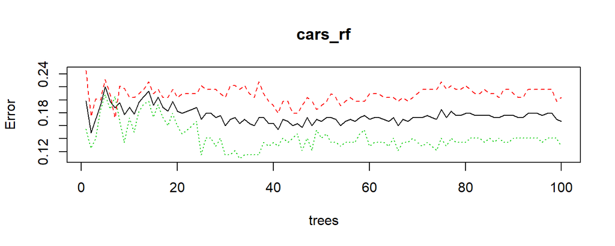

```r
library(randomForest)
cars_rf <- randomForest(factor(expensive) ~ weight + citympg + highwaympg
                        + sports + suv, data=x, subset=(testFlag == 0),
                        ntree=100,proximity=TRUE)

carsPred<-predict(cars_rf,x)
plot(cars_rf)
```

## Random Forest

```r
table(carsPred[x$testFlag==0],x$expensive[x$testFlag==0])
```

```
##
##       0   1
##   0 152   2
##   1  10 154
```

```r
table(carsPred[x$testFlag==1],x$expensive[x$testFlag==1])
```

```
##
##      0  1
##   0 28  4
##   1  4 33
```

## Bake-off

Notice that the neural network with 500 nodes performs similarly to the glm, but the other neural nets under-perform.

**Random Forest** performs very similar to **logistic glm** on test data.

```r
tapply(as.numeric(glm.probs > 0.5) == x$expensive, x$testFlag, mean)
```

```
##         0         1
## 0.8238994 0.8840580
```

```r
tapply(as.numeric(predNnet10 > 0.5) == x$expensive, x$testFlag, mean)
```

```
##         0         1
## 0.5094340 0.4637681
```

## Bake-off (Contd.)

```r
tapply(as.numeric(predNnet500 > 0.5) == x$expensive, x$testFlag, mean)
```

```
##         0         1
## 0.8553459 0.8695652
```

```r
tapply(as.numeric(predNnet900 > 0.5) == x$expensive, x$testFlag, mean)
```

```
##         0         1
## 0.8616352 0.7971014
```

```r
tapply(carsPred == x$expensive, x$testFlag, mean)
```

```
##         0         1
## 0.9622642 0.8840580
```

## Tuning is everything

This is a general property of neural networks that will soon become painfully obvious:

There is some way to construct a very predictive neural network, but unless it is very well tuned it will often get outperformed by much simpler models.

**Keep in mind: a simpler model is often interpretable.**

## Pros and Cons

The **nnet** package is actually quite well written, the *multinom* function is particularly useful, but only handles a single hidden layer.

The **neuralnet** allows for larger models, but I have not extensively tested it.

Quickly construct a visualization of a simple neural network model:

## Visualize Neural Net

```r
library(neuralnet)
out <- neuralnet(expensive ~ weight + citympg + highwaympg + sports + suv,
                  data=x,
                  err.fct="sse",
                  hidden=c(3,2),
                  linear.output=FALSE,
                  likelihood=TRUE)
plot(out)
```

## Visualize Neural Net

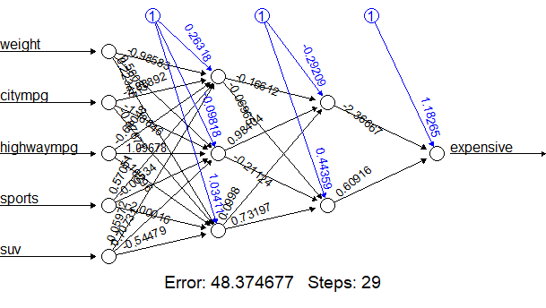

## Compare with Logistic

```
##
## Call:
## glm(formula = expensive ~ weight + citympg + highwaympg + sports +
##     suv, family = binomial, data = x, subset = (testFlag == 0))
##
## Deviance Residuals:
##      Min        1Q    Median        3Q       Max
## -3.09268  -0.58674  -0.00683   0.65447   1.69602
##
## Coefficients:
##               Estimate Std. Error z value Pr(>|z|)
## (Intercept)  0.8315143  4.2239547   0.197 0.843940
## weight       0.0021470  0.0006081   3.531 0.000414 ***
## citympg     -0.3989258  0.1773766  -2.249 0.024510 *
## highwaympg  -0.0211378  0.1204926  -0.175 0.860743
## sports       1.9059571  0.5554153   3.432 0.000600 ***
## suv         -2.5811291  0.6577834  -3.924 8.71e-05 ***
## ---
## Signif. codes:  0 '***' 0.001 '**' 0.01 '*' 0.05 '.' 0.1 ' ' 1
##
## (Dispersion parameter for binomial family taken to be 1)
##
##     Null deviance: 440.73  on 317  degrees of freedom
## Residual deviance: 250.15  on 312  degrees of freedom
## AIC: 262.15
##
## Number of Fisher Scoring iterations: 6
```

## Logistic Coefficients

Effect sizes and P-values

| Effects | Estimate | Exp.Estimate | P.value | Significance |
| --- | --- | --- | --- | --- |
| (Intercept) | 0.8315 | 2.297 | 0.8439 | No |
| weight | 0.002147 | 1.002 | 0.0004142 | Yes |
| citympg | -0.3989 | 0.671 | 0.02451 | Yes |
| highwaympg | -0.02114 | 0.9791 | 0.8607 | No |
| sports | 1.906 | 6.726 | 0.0006001 | Yes |
| suv | -2.581 | 0.07569 | 8.71e-05 | Yes |

## Logistic Coefficients

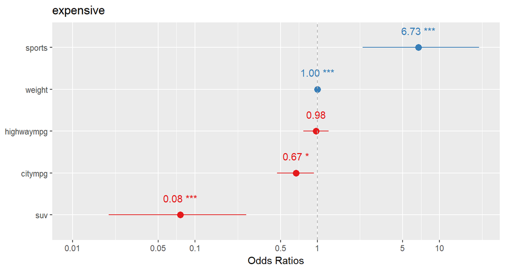

Parameter Estimates for the Fixed Effects

## Compare with random forest

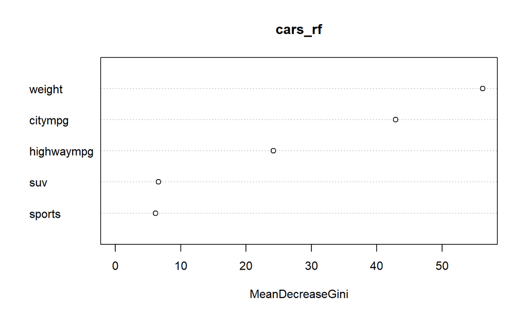

```r
varImpPlot(cars_rf)
```